```python
from google.colab import drive
drive.mount('/content/drive')
```

```python
#%tensorflow_version 2.x
import tensorflow as tf
tf.__version__
```

```
'2.6.0'
```

# PART 1

**Import Data**

```python
import numpy as np       # Library for number operations
import pandas as pd      # Library for data operations

import seaborn as sns
import matplotlib.pyplot as plt
from tensorflow.keras import regularizers, optimizers
from tensorflow.keras.utils import to_categorical
from sklearn.model_selection import train_test_split
from tensorflow.keras.models import load_model
from tensorflow.keras.models import Sequential
from tensorflow.keras.layers import Dense
from keras.layers import BatchNormalization

# read csv file with ";" as seprators
signal_data=pd.read_csv("/content/drive/My Drive/AIML/projects/NN/Part- 1 - Signal.csv",sep=",")

# Display top 5 rows of the dataset
signal_data.head()
```

|  | Parameter 1 | Parameter 2 | Parameter 3 | Parameter 4 | Parameter 5 | Parameter 6 | Parameter 7 | Parameter 8 | Parameter 9 | Parameter 10 | Parameter 11 | Signal_Strength |
| --- | --- | --- | --- | --- | --- | --- | --- | --- | --- | --- | --- | --- |
| 0 | 7.4 | 0.70 | 0.00 | 1.9 | 0.076 | 11.0 | 34.0 | 0.9978 | 3.51 | 0.56 | 9.4 | 5 |
| 1 | 7.8 | 0.88 | 0.00 | 2.6 | 0.098 | 25.0 | 67.0 | 0.9968 | 3.20 | 0.68 | 9.8 | 5 |
| 2 | 7.8 | 0.76 | 0.04 | 2.3 | 0.092 | 15.0 | 54.0 | 0.9970 | 3.26 | 0.65 | 9.8 | 5 |
| 3 | 11.2 | 0.28 | 0.56 | 1.9 | 0.075 | 17.0 | 60.0 | 0.9980 | 3.16 | 0.58 | 9.8 | 6 |
| 4 | 7.4 | 0.70 | 0.00 | 1.9 | 0.076 | 11.0 | 34.0 | 0.9978 | 3.51 | 0.56 | 9.4 | 5 |

**Data analysis & visualisation**

```python
# Shape and size of Data

print("Shape:",signal_data.shape)
print("\nColumns:",signal_data.shape[0])
print("\nRows:",signal_data.shape[1])
print("\nSize:",signal_data.size)
```

[output not shown]

```python
# Checking the presence of missing values
null_counts = signal_data.isnull().sum()  # This prints the columns with the number of null values they have
print (null_counts)
```

```
Parameter 1        0
Parameter 2        0
Parameter 3        0
Parameter 4        0
Parameter 5        0
Parameter 6        0
Parameter 7        0
Parameter 8        0
Parameter 9        0
Parameter 10       0
Parameter 11       0
Signal_Strength    0
dtype: int64
```

**There are no null values in the data**

```python
# check Datatype
signal_data.info()
```

```
<class 'pandas.core.frame.DataFrame'>
RangeIndex: 1599 entries, 0 to 1598
Data columns (total 12 columns):
 #   Column           Non-Null Count  Dtype
---  ------           --------------  -----
 0   Parameter 1      1599 non-null   float64
 1   Parameter 2      1599 non-null   float64
 2   Parameter 3      1599 non-null   float64
 3   Parameter 4      1599 non-null   float64
 4   Parameter 5      1599 non-null   float64
 5   Parameter 6      1599 non-null   float64
 6   Parameter 7      1599 non-null   float64
 7   Parameter 8      1599 non-null   float64
 8   Parameter 9      1599 non-null   float64
 9   Parameter 10     1599 non-null   float64
 10  Parameter 11     1599 non-null   float64
 11  Signal_Strength  1599 non-null   int64
dtypes: float64(11), int64(1)
memory usage: 150.0 KB
```

**All the parameters are floating point and the signal strength is an integer.**

```python
# 5 point summary of numerical attributes
signal_data.describe()
```

|  | Parameter 1 | Parameter 2 | Parameter 3 | Parameter 4 | Parameter 5 | Parameter 6 | Parameter 7 | Parameter 8 | Parameter 9 | Parameter 10 | Parameter 11 | Signal_Strength |
| --- | --- | --- | --- | --- | --- | --- | --- | --- | --- | --- | --- | --- |
| count | 1599.000000 | 1599.000000 | 1599.000000 | 1599.000000 | 1599.000000 | 1599.000000 | 1599.000000 | 1599.000000 | 1599.000000 | 1599.000000 | 1599.000000 | 1599.000000 |
| mean | 8.319637 | 0.527821 | 0.270976 | 2.538806 | 0.087467 | 15.874922 | 46.467792 | 0.996747 | 3.311113 | 0.658149 | 10.422983 | 5.636023 |
| std | 1.741096 | 0.179060 | 0.194801 | 1.409928 | 0.047065 | 10.460157 | 32.895324 | 0.001887 | 0.154386 | 0.169507 | 1.065668 | 0.807569 |
| min | 4.600000 | 0.120000 | 0.000000 | 0.900000 | 0.012000 | 1.000000 | 6.000000 | 0.990070 | 2.740000 | 0.330000 | 8.400000 | 3.000000 |
| 25% | 7.100000 | 0.390000 | 0.090000 | 1.900000 | 0.070000 | 7.000000 | 22.000000 | 0.995600 | 3.210000 | 0.550000 | 9.500000 | 5.000000 |
| 50% | 7.900000 | 0.520000 | 0.260000 | 2.200000 | 0.079000 | 14.000000 | 38.000000 | 0.996750 | 3.310000 | 0.620000 | 10.200000 | 6.000000 |
| 75% | 9.200000 | 0.640000 | 0.420000 | 2.600000 | 0.090000 | 21.000000 | 62.000000 | 0.997835 | 3.400000 | 0.730000 | 11.100000 | 6.000000 |
| max | 15.900000 | 1.580000 | 1.000000 | 15.500000 | 0.611000 | 72.000000 | 289.000000 | 1.003690 | 4.010000 | 2.000000 | 14.900000 | 8.000000 |

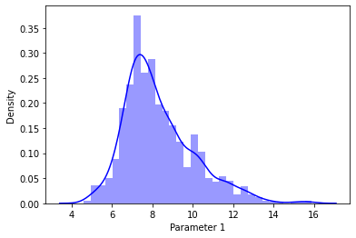

```
Distribution of  Parameter 1
Mean is: 8.319637273295838
Median is: 7.9
Mode is: 0    7.2
dtype: float64
Standard deviation is: 1.7410963181277006
Skewness is: 0.9827514413284587
Maximum is: 15.9
Minimum is: 4.6
```

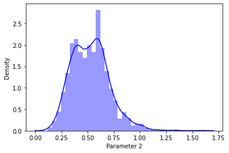

```
Distribution of  Parameter 2
Mean is: 0.5278205128205131
Median is: 0.52
Mode is: 0    0.6
dtype: float64
Standard deviation is: 0.17905970415353498
Skewness is: 0.6715925723840199
Maximum is: 1.58
Minimum is: 0.12
```

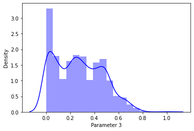

```
Distribution of  Parameter 3
Mean is: 0.2709756097560964
Median is: 0.26
Mode is: 0    0.0
dtype: float64
Standard deviation is: 0.19480113740531785
Skewness is: 0.3183372952546368
Maximum is: 1.0
Minimum is: 0.0
```

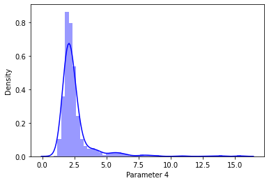

```
Distribution of  Parameter 4
Mean is: 2.5388055034396517
Median is: 2.2
Mode is: 0    2.0
dtype: float64
Standard deviation is: 1.4099280595072805
Skewness is: 4.54065542590319
Maximum is: 15.5
Minimum is: 0.9
```

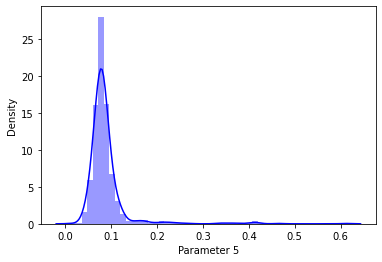

```
Distribution of  Parameter 5
Mean is: 0.08746654158849257
Median is: 0.079
Mode is: 0    0.08
dtype: float64
Standard deviation is: 0.047065302010090154
Skewness is: 5.680346571971722
Maximum is: 0.611
Minimum is: 0.012
```

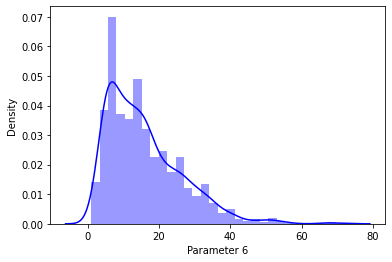

```
Distribution of  Parameter 6
Mean is: 15.874921826141339
Median is: 14.0
Mode is: 0    6.0
dtype: float64
Standard deviation is: 10.46015696980973
Skewness is: 1.250567293314441
Maximum is: 72.0
Minimum is: 1.0
```

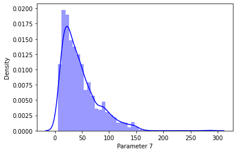

```
Distribution of  Parameter 7
Mean is: 46.46779237023139
Median is: 38.0
Mode is: 0    28.0
dtype: float64
Standard deviation is: 32.89532447829901
Skewness is: 1.515531257594554
Maximum is: 289.0
Minimum is: 6.0
```

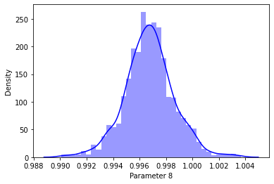

```
Distribution of  Parameter 8
Mean is: 0.9967466791744833
Median is: 0.99675
Mode is: 0    0.9972
dtype: float64
Standard deviation is: 0.0018873339538425563
Skewness is: 0.07128766294945525
Maximum is: 1.00369
Minimum is: 0.9900700000000001
```

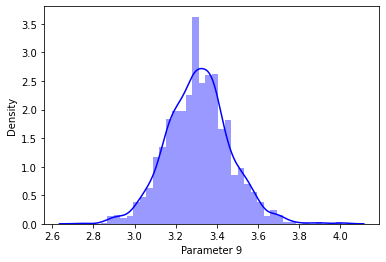

```
Distribution of  Parameter 9
Mean is: 3.311113195747343
Median is: 3.31
Mode is: 0    3.3
dtype: float64
Standard deviation is: 0.15438646490354266
Skewness is: 0.19368349811284427
Maximum is: 4.01
Minimum is: 2.74
```

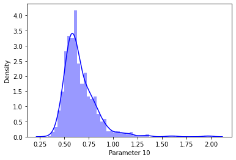

```
Distribution of  Parameter 10
Mean is: 0.6581488430268921
Median is: 0.62
Mode is: 0    0.6
dtype: float64
Standard deviation is: 0.16950697959010977
Skewness is: 2.4286723536602945
Maximum is: 2.0
Minimum is: 0.33
```

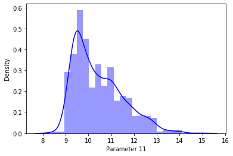

```
Distribution of  Parameter 11
Mean is: 10.422983114446502
Median is: 10.2
Mode is: 0    9.5
dtype: float64
Standard deviation is: 1.0656675818563965
Skewness is: 0.8608288069184189
Maximum is: 14.9
Minimum is: 8.4
```

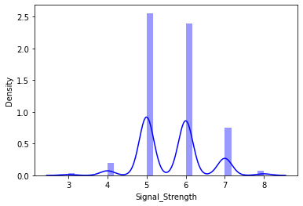

```
Distribution of  Signal_Strength
Mean is: 5.6360225140712945
Median is: 6.0
Mode is: 0    5
dtype: int64
Standard deviation is: 0.8075694397347023
Skewness is: 0.21780157547366327
Maximum is: 8
Minimum is: 3
```

```python
# studying the distribution of continuous attributes
cols = list(signal_data)
for i in np.arange(len(cols)):
    sns.distplot(signal_data[cols[i]], color='blue')
    #plt.xlabel('Experience')
    plt.show()
    print('Distribution of ',cols[i])
    print('Mean is:',signal_data[cols[i]].mean())
    print('Median is:',signal_data[cols[i]].median())
    print('Mode is:',signal_data[cols[i]].mode())
    print('Standard deviation is:',signal_data[cols[i]].std())
    print('Skewness is:',signal_data[cols[i]].skew())
    print('Maximum is:',signal_data[cols[i]].max())
    print('Minimum is:',signal_data[cols[i]].min())
```

**Looking the 11 parameters : Parameter 3 ranges between 0 and 1. Maximum value of Parameter 5 is 0.6 Parameter 8 has a very low range between 0.9 and 1.004 Standard deviation is lowest for Parameter 8, it is 0.001887, Standarddeviation is maximum for Parameter7, it is 32.89532447829901 'Signal_Strength' has classes as - 3.0, 4.0,5.0, 6.0, 7.0 and 8.0**

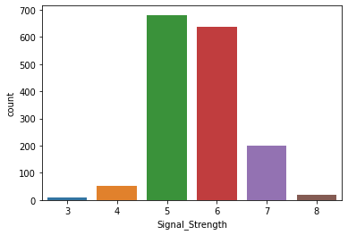

```python
sns.countplot(signal_data['Signal_Strength'])    # Distibution of the column 'Signal_Strength'
plt.show()
```

**class 5.0 in 'Signal_Strength' has the highest count.**

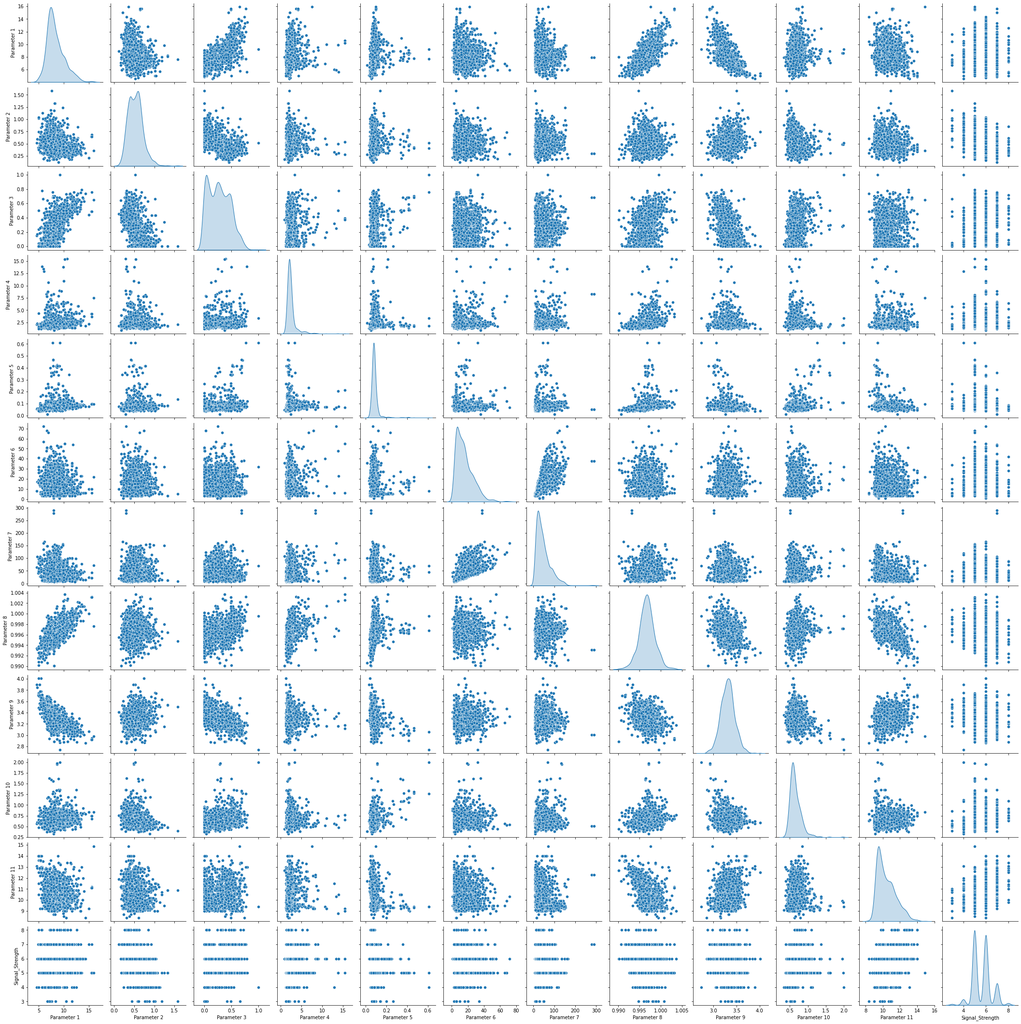

```python
sns.pairplot(signal_data,diag_kind='kde')
plt.show()
```

**1.Parameter 6 and Parameter 7 are highly correlated with each other and visce versa and they have almost 0 correlation with other Parameters. 2.Parameter 1 is positively correlated to Parameter 3 and Parameter 8 and negatively correlated to Parameter 2 and Parameter 9. 3.Parameter 4 is has very low correlation with other Parameters.**

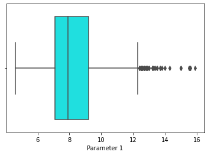

```
Boxplot of  Parameter 1
Q1 is :  7.1
Q2 is :  7.9
Q3 is :  9.2
IQR is: 2.0999999999999996
Lower Whisker, Upper Whisker :  3.95 , 12.349999999999998
Out of  1599  rows in data, number of outliers are: 49
```

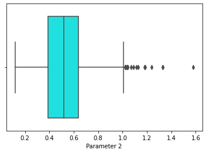

```
Boxplot of  Parameter 2
Q1 is :  0.39
Q2 is :  0.52
Q3 is :  0.64
IQR is: 0.25
Lower Whisker, Upper Whisker :  0.015000000000000013 , 1.0150000000000001
Out of  1599  rows in data, number of outliers are: 19
```

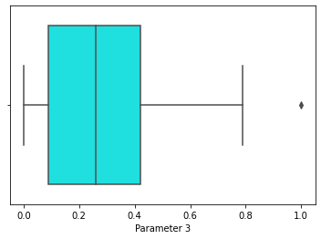

```
Boxplot of  Parameter 3
Q1 is :  0.09
Q2 is :  0.26
Q3 is :  0.42
IQR is: 0.32999999999999996
Lower Whisker, Upper Whisker :  -0.4049999999999999 , 0.9149999999999999
Out of  1599  rows in data, number of outliers are: 1
```

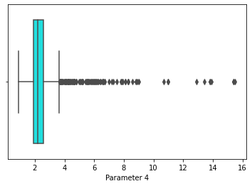

```
Boxplot of  Parameter 4
Q1 is :  1.9
Q2 is :  2.2
Q3 is :  2.6
IQR is: 0.7000000000000002
Lower Whisker, Upper Whisker :  0.8499999999999996 , 3.6500000000000004
Out of  1599  rows in data, number of outliers are: 155
```

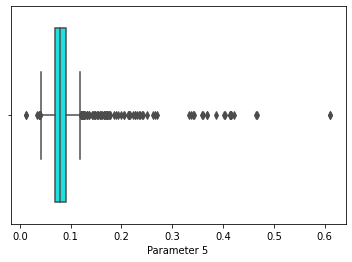

```
Boxplot of  Parameter 5
Q1 is :  0.07
Q2 is :  0.079
Q3 is :  0.09
IQR is: 0.01999999999999999
Lower Whisker, Upper Whisker :  0.04000000000000002 , 0.11999999999999998
Out of  1599  rows in data, number of outliers are: 112
```

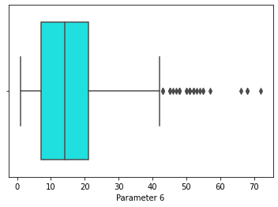

```
Boxplot of  Parameter 6
Q1 is :  7.0
Q2 is :  14.0
Q3 is :  21.0
IQR is: 14.0
Lower Whisker, Upper Whisker :  -14.0 , 42.0
Out of  1599  rows in data, number of outliers are: 30
```

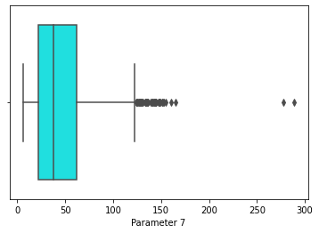

```
Boxplot of  Parameter 7
Q1 is :  22.0
Q2 is :  38.0
Q3 is :  62.0
IQR is: 40.0
Lower Whisker, Upper Whisker :  -38.0 , 122.0
Out of  1599  rows in data, number of outliers are: 55
```

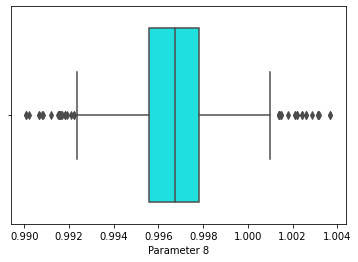

```
Boxplot of  Parameter 8
Q1 is :  0.9956
Q2 is :  0.99675
Q3 is :  0.9978349999999999
IQR is: 0.002234999999999876
Lower Whisker, Upper Whisker :  0.9922475000000002 , 1.0011874999999997
Out of  1599  rows in data, number of outliers are: 45
```

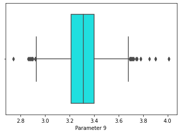

```
Boxplot of  Parameter 9
Q1 is :  3.21
Q2 is :  3.31
Q3 is :  3.4
IQR is: 0.18999999999999995
Lower Whisker, Upper Whisker :  2.925 , 3.6849999999999996
Out of  1599  rows in data, number of outliers are: 35
```

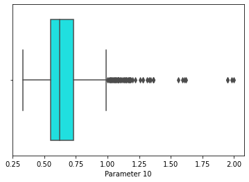

```
Boxplot of  Parameter 10
Q1 is :  0.55
Q2 is :  0.62
Q3 is :  0.73
IQR is: 0.17999999999999994
Lower Whisker, Upper Whisker :  0.28000000000000014 , 0.9999999999999999
Out of  1599  rows in data, number of outliers are: 59
```

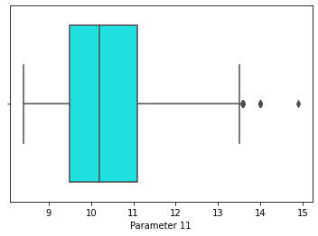

```
Boxplot of  Parameter 11
Q1 is :  9.5
Q2 is :  10.2
Q3 is :  11.1
IQR is: 1.5999999999999996
Lower Whisker, Upper Whisker :  7.1000000000000005 , 13.5
Out of  1599  rows in data, number of outliers are: 13
```

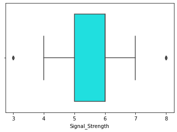

```
Boxplot of  Signal_Strength
Q1 is :  5.0
Q2 is :  6.0
Q3 is :  6.0
IQR is: 1.0
Lower Whisker, Upper Whisker :  3.5 , 7.5
Out of  1599  rows in data, number of outliers are: 28
```

```python
#Find outliers
l = len(signal_data)
col = list(signal_data.columns)
for i in np.arange(len(col)):
    sns.boxplot(x= signal_data[col[i]], color='cyan')
    plt.show()
    print('Boxplot of ',col[i])
    #calculating the outiers in attribute
    Q1 = signal_data[col[i]].quantile(0.25)
    Q2 = signal_data[col[i]].quantile(0.50)
    Q3 = signal_data[col[i]].quantile(0.75)
    IQR = Q3 - Q1
    L_W = (Q1 - 1.5 *IQR)
    U_W = (Q3 + 1.5 *IQR)
    print('Q1 is : ',Q1)
    print('Q2 is : ',Q2)
    print('Q3 is : ',Q3)
    print('IQR is:',IQR)
    print('Lower Whisker, Upper Whisker : ',L_W,',',U_W)
    bools = (signal_data[col[i]] < (Q1 - 1.5 *IQR)) |(signal_data[col[i]] > (Q3 + 1.5 * IQR))
    print('Out of ',l,' rows in data, number of outliers are:',bools.sum())
```

```python
#  function to treat outliers
def detect_treate_outliers(df,operation):
    cols=[]
    IQR_list=[]
    lower_boundary_list=[]
    upper_boundary_list=[]
    outliers_count=[]
    for col in df.columns:
        #print('col',col)
        if((df[col].dtype =='int64' or df[col].dtype =='float64') and (col != 'HR')):
            #print('Inside if')
            IQR = df[col].quantile(0.75) - df[col].quantile(0.25)
            lower_boundary = df[col].quantile(0.25) - (1.5 * IQR)
            upper_boundary = df[col].quantile(0.75) + (1.5 * IQR)
            up_cnt = df[df[col]>upper_boundary][col].shape[0]
            #print('Upper count=',up_cnt)
            lw_cnt = df[df[col]<lower_boundary][col].shape[0]
            #print('lower count=',lw_cnt)
            if(up_cnt+lw_cnt) > 0:
                cols.append(col)
                IQR_list.append(IQR)
                lower_boundary_list.append(lower_boundary)
                upper_boundary_list.append(upper_boundary)
                outliers_count.append(up_cnt+lw_cnt)
                if operation == 'update':
                    df.loc[df[col] > upper_boundary,col] = upper_boundary
                    df.loc[df[col] < lower_boundary,col] = lower_boundary
                else:
                    pass
            else:
                pass
   #print('cols=',cols)
   # print('IQR_list=',IQR_list)
   # print('lower_boundary_list=',lower_boundary_list)
   # print('upper_boundary_list=',upper_boundary_list)
   # print('outliers_count=',outliers_count)
    ndf = pd.DataFrame(list(zip(cols,IQR_list,lower_boundary_list,upper_boundary_list,outliers_count)),columns=['Features','IQR','Lower Boundary','Upper Boundary','Outlier Count'])
    #print('Data=',ndf)
    #print('Columns having outliers=',cols)
    if operation == 'update':
        return (len(cols),df)
    else:
        return (len(cols),ndf)
```

```python
#Removing outliers by replacing the data below lower whisker with it and above upper whisker with it respectively.
count,df=detect_treate_outliers(signal_data,'update')
if count>0:
    print('Updating dataset')
    signal_data=df
```

```
Updating dataset
```

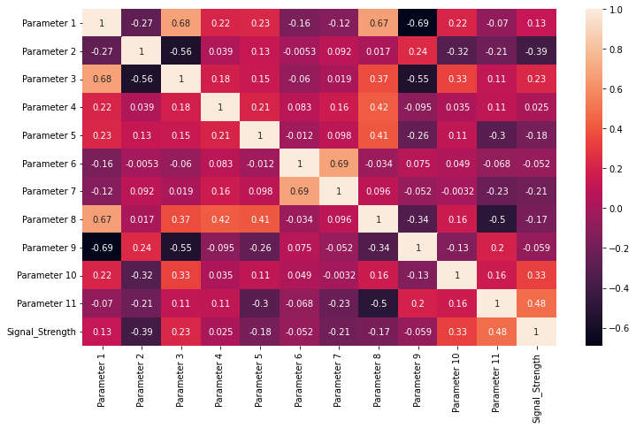

```python
b_corr=signal_data.corr()
plt.subplots(figsize =(12, 7))
sns.heatmap(b_corr,annot=True)
```

**Since high correlation coefficient value lies between ± 0.50 and ± 1 Parameter 1 is highly correlated with Parameter 3 and Parameter 8, Parameter 9. Parameter 6 and 7 are highly correlated. But since, the correlation is not too high near 0.8 or above not dropping the features.**

**Design, train, tune and test a neural network regressor.**

```python
#Seperate independent variables and target variables
X = signal_data.drop("Signal_Strength", axis=1)
y = signal_data['Signal_Strength']
```

```python
# splitting to create test data
X_vtrain, X_test, y_vtrain, y_test = train_test_split(X, y, test_size=.30, random_state=7)
```

```python
X_vtrain.shape
```

```
(1119, 11)
```

```python
# splitting to create training and validation data
X_train, X_val, y_train, y_val = train_test_split(X_vtrain, y_vtrain, test_size=.20, random_state=7)
```

```python
X_train.shape
```

```
(895, 11)
```

```python
# Initialize Sequential model

model_reg = tf.keras.models.Sequential()

# Normalize input data
model_reg.add(tf.keras.layers.BatchNormalization(input_shape=(11,)))

# Add final Dense layer for prediction - Tensorflow.keras declares weights and bias automatically
model_reg.add(tf.keras.layers.Dense(1))
```

```python
# Compile the model - add mean squared error as loss and stochastic gradient descent as optimizer
sgd = optimizers.SGD(learning_rate = 0.001)
model_reg.compile(optimizer=sgd, loss='mse')
```

```python
model_reg.fit(X_train, y_train, validation_data=(X_val,y_val),epochs=100, batch_size=20)
```

```
<keras.callbacks.History at 0x7fa246df7ad0>
```

**Pickle the model for future use.**

```python
# save the model
model_reg.save("model_reg.h5") #using h5 extension
print("model saved!!!")
```

```
model saved!!!
```

```python
# load the model
model_rr = load_model('model_reg.h5')
```

```python
y_pred = model_rr.predict(X_test)
```

```python
print(y_pred[0])
print(y_pred[1])
print(y_pred[2])
print(y_pred[3])
print(y_pred[4])
```

```
[5.739338]
[5.7696443]
[5.8208814]
[5.3265076]
[6.076963]
```

```python
print(y_test.head())
```

```
1526    6.0
674     6.0
1508    6.0
58      5.0
1351    6.0
Name: Signal_Strength, dtype: float64
```

```python
from sklearn.metrics import r2_score
score_r = r2_score(y_test,y_pred)
print(score_r)
```

```
0.32419432633628054
```

```python
#summary of regression model
model_rr.summary()
```

```
Model: "sequential_9"
_________________________________________________________________
Layer (type)                 Output Shape              Param #
=================================================================
batch_normalization_17 (Batc (None, 11)                44
_________________________________________________________________
dense_24 (Dense)             (None, 1)                 12
=================================================================
Total params: 56
Trainable params: 34
Non-trainable params: 22
_________________________________________________________________
```

**The first 5 elements of y_pred and y_test are close.**

# PROJECT OBJECTIVE: The need is to build a classifier which can use these parameters to determine the signal strength or quality

**Steps 1 and 2 are same as for the regressor above**

**Design, train, tune and test a neural network classifier.**

```python
# counting the number of classes in output
signal_data['Signal_Strength'].value_counts()
```

```
5.0    681
6.0    638
7.0    199
4.0     53
7.5     18
3.5     10
Name: Signal_Strength, dtype: int64
```

```python
X.shape
```

```
(1599, 11)
```

```python
y.shape
```

```
(1599,)
```

```python
# converting y data into categorical (one-hot encoding)

yc = to_categorical(y, num_classes=8)
```

```python
# splitting data for test of categorial
Xcv_train, Xc_test, ycv_train, yc_test = train_test_split(X, yc, test_size=.30, random_state=7)
```

```python
print("Shape of y_train:", ycv_train.shape)
print("One value of y_train:", ycv_train[0])
```

```
Shape of y_train: (1119, 8)
One value of y_train: [0. 0. 0. 0. 0. 0. 0. 1.]
```

```python
# splitting data for  train and validation of categorial
Xc_train, Xc_val, yc_train, yc_val = train_test_split(Xcv_train, ycv_train, test_size=.20, random_state=7)
```

```python
print("Shape of y_train:", yc_train.shape)
print("One value of y_train:", yc_train[0])
```

```
Shape of y_train: (895, 8)
One value of y_train: [0. 0. 0. 0. 0. 1. 0. 0.]
```

**Initialize a sequential model again**

1. Define a sequential model
2. Added 3 Dense layers
3. 2 Dense Layers Activation: "relu"
4. Output Dense layer Activation: "softmax"
5. Optimizer : Adam
6. Loss : categorical_crossentropy
7. Batch Size : 20
8. learning_rate = 0.01
9. epochs=100

```python
#NN Model

model_class = Sequential()

model_class.add(tf.keras.Input(shape=(11,)))
model_class.add(Dense(11, activation='relu', kernel_initializer="random_normal"))
model_class.add(Dense(8, activation='relu', kernel_initializer="random_normal"))
model_class.add(Dense(8, activation='softmax', kernel_initializer="random_normal"))
```

```python
# Compile the model
from tensorflow.keras import optimizers
adam = optimizers.Adam(learning_rate = 0.01)
model_class.compile(loss="categorical_crossentropy", metrics=["accuracy"], optimizer=adam)
```

```python
# Fit the model
model_class.fit(x=Xc_train, y=yc_train, batch_size=20, epochs=100, validation_data=(Xc_val, yc_val))
```

```
<keras.callbacks.History at 0x7fa246c50a50>
```

**Pickle the model for future use.**

```python
# save the model
model_class.save("model_class.h5") #using h5 extension
print("model saved!!!")
```

```
model saved!!!
```

```python
# load the model
model_cl = load_model('model_class.h5')
```

```python
# calculate score of training data
score = model_cl.evaluate(Xc_train, yc_train, verbose=0)
print(score)
```

```
[0.9120978713035583, 0.5832402110099792]
```

```python
# score of test data
score_t = model_cl.evaluate(Xc_test, yc_test, verbose=0)
print( score_t)
```

```
[0.9251797795295715, 0.5979166626930237]
```

```python
#summary of classification model
model_cl.summary()
```

```
Model: "sequential_11"
_________________________________________________________________
Layer (type)                 Output Shape              Param #
=================================================================
dense_28 (Dense)             (None, 11)                132
_________________________________________________________________
dense_29 (Dense)             (None, 8)                 96
_________________________________________________________________
dense_30 (Dense)             (None, 8)                 72
=================================================================
Total params: 300
Trainable params: 300
Non-trainable params: 0
_________________________________________________________________
```

# **Part2**

**Import the data.**

```python
import h5py
from tensorflow.keras.utils import to_categorical
from tensorflow.keras import optimizers
from tensorflow.keras.models import Sequential
from tensorflow.keras.layers import Dense
from keras.layers import BatchNormalization

# Open the file as readonly
h5f = h5py.File('/content/drive/My Drive/AIML/projects/NN/Part - 4 - Autonomous_Vehicles_SVHN_single_grey1.h5', 'r')

h5f.keys()
```

```
<KeysViewHDF5 ['X_test', 'X_train', 'X_val', 'y_test', 'y_train', 'y_val']>
```

**Data pre-processing and visualisation.**

```python
# Load the training, test and validation set
X_train = h5f['X_train'][:]
y_train = h5f['y_train'][:]
X_test = h5f['X_test'][:]
y_test = h5f['y_test'][:]
```

```python
#Checking few contents of features and labels of one example from the images
X_train[:1]
```

```
array([[[ 33.0704,  30.2601,  26.852 , ...,  71.4471,  58.2204,
          42.9939],
        [ 25.2283,  25.5533,  29.9765, ..., 113.0209, 103.3639,
          84.2949],
        [ 26.2775,  22.6137,  40.4763, ..., 113.3028, 121.775 ,
         115.4228],
        ...,
        [ 28.5502,  36.212 ,  45.0801, ...,  24.1359,  25.0927,
          26.0603],
        [ 38.4352,  26.4733,  23.2717, ...,  28.1094,  29.4683,
          30.0661],
        [ 50.2984,  26.0773,  24.0389, ...,  49.6682,  50.853 ,
          53.0377]]], dtype=float32)
```

```python
y_train[:1]
```

```
array([2], dtype=uint8)
```

```python
X_test[:1]
```

```
array([[[ 40.558 ,  46.7917,  48.9764, ..., 112.1153, 112.9904,
         112.1646],
        [ 39.4379,  44.2911,  47.1768, ..., 111.0122, 110.9475,
         109.9368],
        [ 38.4488,  43.6394,  48.7098, ..., 109.8921, 109.9414,
         109.1048],
        ...,
        [ 34.9869,  35.4707,  39.6676, ..., 109.211 , 109.9074,
         112.7346],
        [ 35.6602,  35.5462,  40.3193, ..., 110.9998, 112.049 ,
         114.3431],
        [ 36.1871,  35.4214,  40.6998, ..., 110.0169, 111.2017,
         114.1906]]], dtype=float32)
```

```python
y_test[:1]
```

```
array([1], dtype=uint8)
```

**Visualising the first 10 images in the dataset.**

[output not shown]

```python
# visualizing the first 10 images in the dataset and their labels
%matplotlib inline
import matplotlib.pyplot as plt
plt.figure(figsize=(10, 1))
for i in range(10):
    plt.subplot(1, 10, i+1)
    plt.imshow(X_train[i], cmap="gray")
    plt.axis('off')
plt.show()
print('label for each of the above image: %s' % (y_train[0:10]))
```

[output not shown]

**Checking the shape of the data**

```python
X_train.shape
```

```
(42000, 32, 32)
```

```python
y_train.shape
```

```
(42000,)
```

**Need to reshape the X_train and X_test so that the same can be fed for model building.RESHAPE 2D - 32*32 into 1D - 1024.We will normalize the data. We divide by 255 as this is a grayscale image and can take values from 0-255**

```python
X_train = X_train.reshape(X_train.shape[0], 1024)
X_test = X_test.reshape(X_test.shape[0], 1024)

# # normalize inputs from 0-255 to 0-1
X_train = X_train / 255.0
X_test = X_test / 255.0

print('Resized Training set', X_train.shape, y_train.shape)
print('Resized Test set', X_test.shape, y_test.shape)
```

```
Resized Training set (42000, 1024) (42000,)
Resized Test set (18000, 1024) (18000,)
```

**Encoding the target variables. We need to one hot encode the labels for the model to understand the labels better. We will be using categorical cross entropy as our loss function and for this purpose we need our labels to be in one hot encoded format.**

```python
# one hot encode outputs
y_train = to_categorical(y_train)
y_test = to_categorical(y_test)

# no.of classes
num_classes = y_test.shape[1]
print("The number of classes in this dataset are:",num_classes)
```

```
The number of classes in this dataset are: 10
```